# Regression Diagnostics: The SHIN Checks

Reading `check_model()` plots by eye — Shape, Homoscedasticity, Influential points, Normality

RSR Resources

2026-06-27

> **How to use this document (instructor notes).** We build everything live, one `tribble()` at a time. The rhythm for each assumption is always the same: **(1) load a dataset, (2) fit a model, (3) run `check_model()`, (4) look at the relevant panel and decide.** We deliberately start with the *bad* version (so the violation is obvious), then the *good* version (so we know what “clean” looks like), then an *in-between* version (so students learn that real data lives in the grey zone).

> We are **not** covering the formal tests or the statistical consequences of each violation here. For that — what actually goes wrong, the formal tests, and how to fix it — point students to the **Regression Assumptions Explorer**. Today is purely about training the eye.

# Setup

We only need two packages today: the tidyverse (for `tribble()` and plotting) and **performance**, which gives us the one-stop `check_model()` diagnostic panel.

```r
library(tidyverse)   # tribble(), ggplot2, dplyr
library(performance) # check_model()
```

A tiny helper so we are not repeating ourselves. Give it a dataset and a formula, it fits the model and draws the full diagnostic panel.

```r
diagnose <- function(data, formula) {
  model <- lm(formula, data = data)
  print(check_model(model))
  invisible(model)
}
```

## The four checks: SHIN

`check_model()` draws several panels. Today we read just four of them — easy to remember as **SHIN**:

| Letter | Check | Plot to read | Question to ask |
| --- | --- | --- | --- |
| **S** | **Shape** (linearity) | *Linearity* (residuals vs fitted) | Does the green line stay flat near zero? |
| **H** | **Homoscedasticity** | *Homogeneity of variance* (scale–location) | Does the green line stay flat / spread stay even? |
| **I** | **Influential points** | *Influential observations* (residuals vs leverage) | Does any point sit outside the dashed contour? |
| **N** | **Normality** of residuals | *Normality of residuals* (Q–Q plot) | Do the dots hug the diagonal line? |

That is the whole game: fit the model, find the right panel, ask the question.

# S — Shape (Linearity)

**The question:** is the relationship actually a straight line? We read the **Linearity** panel (residuals vs fitted). A flat green line near zero is good; a U-shape or arch means the relationship bends and a straight line is the wrong model.

## Start with the bad one

Weekly study hours vs. quiz score. Going from no studying to moderate studying helps a lot; extra hours past that add little because you are brushing the top of the scale. That is a curve, not a line.

```r
shape_bad <- tribble(
  ~study_hours, ~quiz_score,
  2, 20.4,
  5, 36.5,
  8, 53.7,
  11, 65.4,
  14, 73.2,
  18, 79.9,
  22, 88.7,
  27, 89.3,
  32, 96.5,
  38, 93.7,
  44, 97.7,
  50, 99.5,
  56, 92.6,
  60, 95.1
)
```

Look at the raw scatter first — you can often already see the bend.

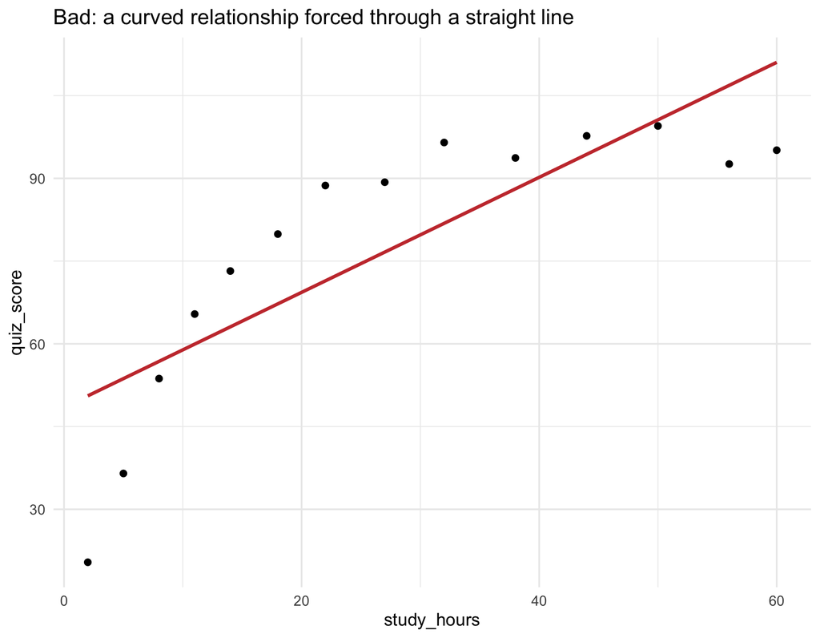

```r
ggplot(shape_bad, aes(study_hours, quiz_score)) +
  geom_point(size = 2) +
  geom_smooth(method = "lm", se = FALSE, colour = "#C83B3B") +
  labs(title = "Bad: a curved relationship forced through a straight line") +
  theme_minimal(base_size = 14)
```

Now the diagnostic panel. **Watch the Linearity panel.**

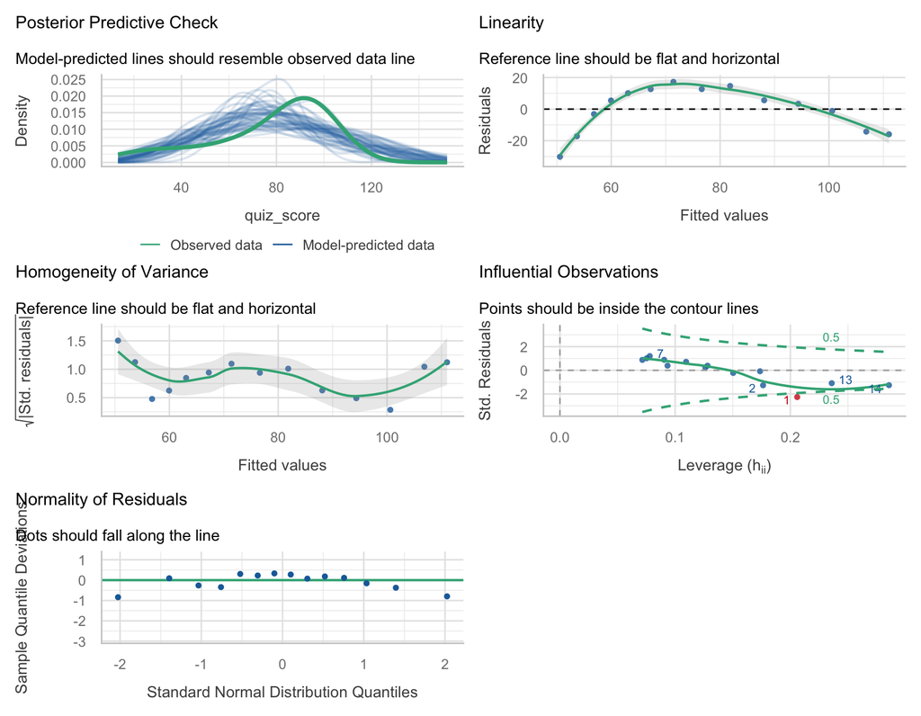

```r
diagnose(shape_bad, quiz_score ~ study_hours)
```

> **What to point out:** the green line in the *Linearity* panel arches — residuals are negative in the middle and positive at the ends (or vice versa). That systematic shape is the signature of a non-linear relationship.

## Now the good one

Weekly exercise hours vs. VO₂ max — a clean, genuinely linear relationship.

```r
shape_good <- tribble(
  ~exercise_hours, ~vo2_max,
  1, 29.4,
  2, 32,
  3, 32.4,
  4, 30.9,
  5, 32.8,
  6, 39.3,
  7, 38.8,
  8, 38.5,
  9, 42.2,
  10, 45.6,
  11, 48.1,
  12, 46.6,
  13, 48.5,
  14, 48.1
)
```

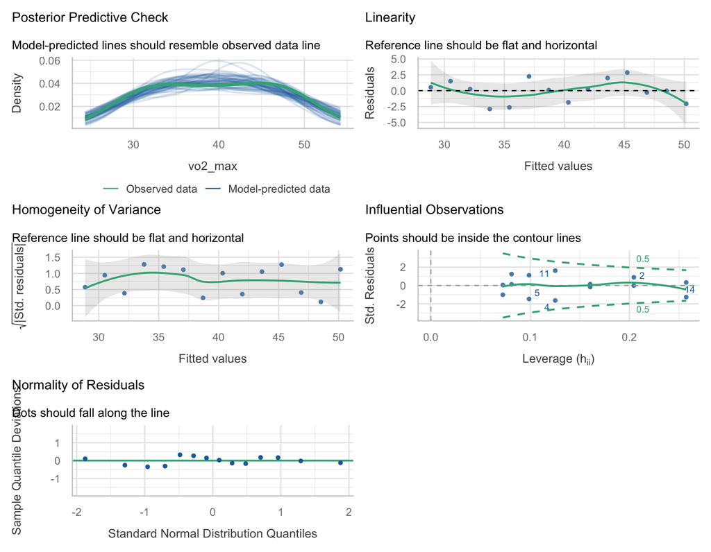

```r
diagnose(shape_good, vo2_max ~ exercise_hours)
```

> **What to point out:** the *Linearity* green line is essentially flat and sits on zero. No leftover pattern — a straight line was the right choice.

## The in-between one

Age vs. systolic blood pressure. BP rises with age and may accelerate *slightly* at older ages. Subtle enough to argue about — which is the point.

```r
shape_border <- tribble(
  ~age, ~systolic_bp,
  25, 115,
  28, 114,
  32, 120,
  36, 123,
  40, 128,
  44, 126,
  48, 132,
  52, 129,
  56, 135,
  60, 139,
  64, 138,
  68, 149,
  72, 154,
  76, 156
)
```

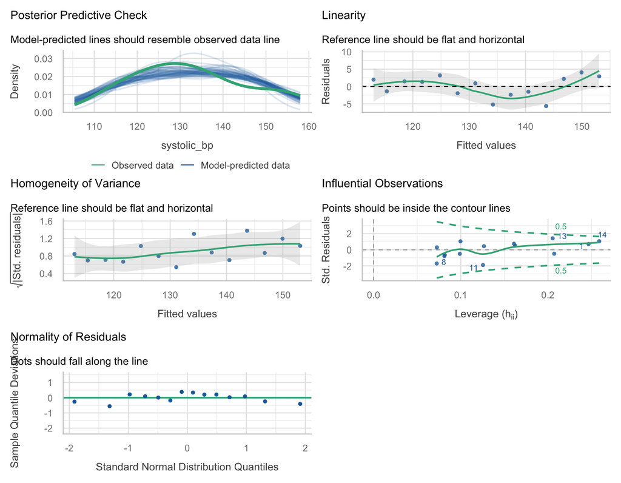

```r
diagnose(shape_border, systolic_bp ~ age)
```

> **What to point out:** the green line has a gentle tilt or slight bow, but it is not a dramatic U. This is the realistic case — “good enough for a linear approximation, but keep an eye on it.”

## Practice — Shape

1. In the **bad** panel, the residuals-vs-fitted smoother makes an arch. In your own words, why does a straight line *guarantee* this pattern when the truth is a curve?
2. A colleague says “the positive and negative residuals sum to zero, so linearity is fine.” Why is that reasoning wrong?
3. For the **borderline** BP data, would you report the linear slope as-is, or would you want a second look? What would you check?

# H — Homoscedasticity (Equal Variance)

**The question:** does the *spread* of the residuals stay constant across the range? We read the **Homogeneity of variance** panel (scale–location). A flat green line means even spread; an upward ramp means the scatter fans out.

## Start with the bad one

Household income vs. out-of-pocket medical spending. Wealthier households have far more discretionary spending, so the spread balloons at the high end — the classic fan shape.

```r
hom_bad <- tribble(
  ~income_k, ~medical_spend,
  20, 576,
  28, 353,
  35, 189,
  42, 868,
  48, 425,
  55, 1575,
  62, 703,
  68, 1417,
  75, 1317,
  82, 606,
  90, 2556,
  98, 1943,
  108, 1583,
  120, 1939
)
```

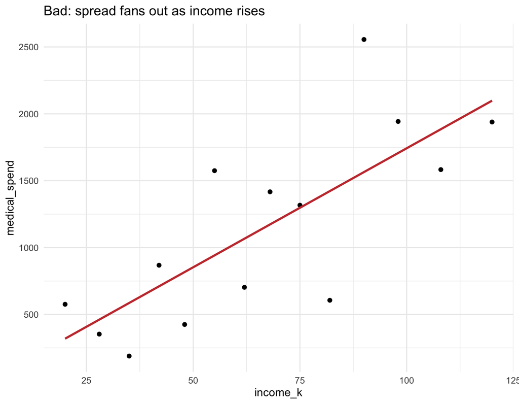

```r
ggplot(hom_bad, aes(income_k, medical_spend)) +
  geom_point(size = 2) +
  geom_smooth(method = "lm", se = FALSE, colour = "#C83B3B") +
  labs(title = "Bad: spread fans out as income rises") +
  theme_minimal(base_size = 14)
```

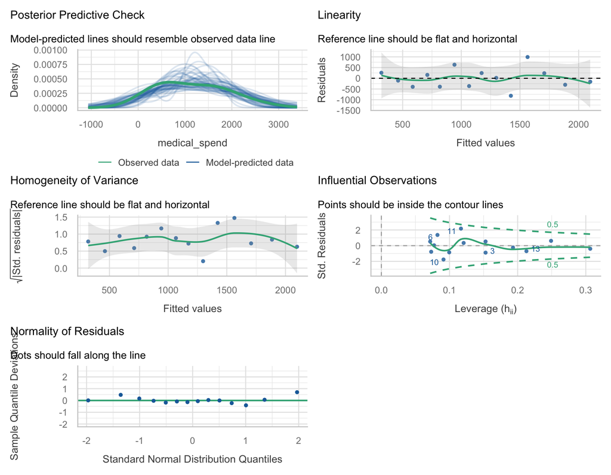

```r
diagnose(hom_bad, medical_spend ~ income_k)
```

## Now the good one

Exercise duration vs. calories burned. The spread looks the same for short and long workouts.

```r
hom_good <- tribble(
  ~exercise_min, ~calories,
  15, 144,
  20, 167,
  25, 162,
  30, 227,
  35, 249,
  40, 284,
  45, 317,
  50, 355,
  55, 361,
  60, 412,
  63, 419,
  18, 166,
  34, 257,
  52, 360
)
```

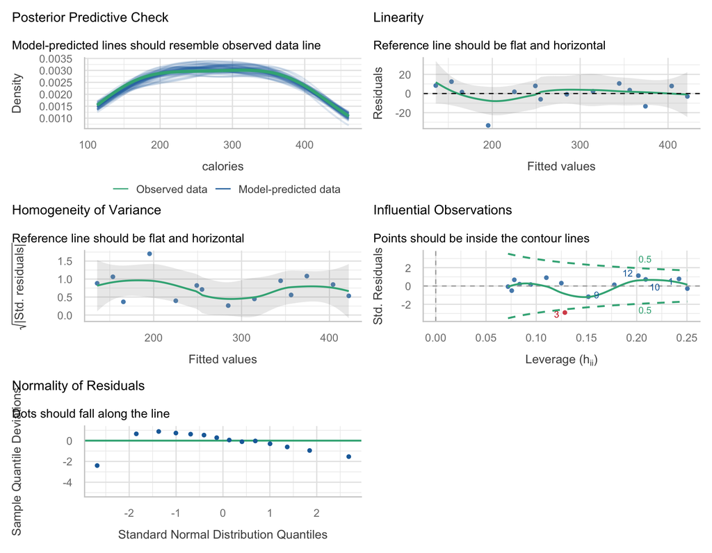

```r
diagnose(hom_good, calories ~ exercise_min)
```

> **What to point out:** the *Homogeneity* green line is roughly flat — the band of points has even thickness from left to right.

## The in-between one

Years of education vs. health literacy score. The spread widens *a little* at higher education levels, but it is mild.

```r
hom_border <- tribble(
  ~education_yrs, ~health_literacy,
  8, 52.1,
  9, 56,
  10, 60.2,
  11, 63.6,
  12, 67.7,
  12, 68.4,
  13, 72.6,
  14, 76.5,
  15, 79,
  16, 82.5,
  17, 90.3,
  18, 92.4,
  19, 96.2,
  20, 99.7
)
```

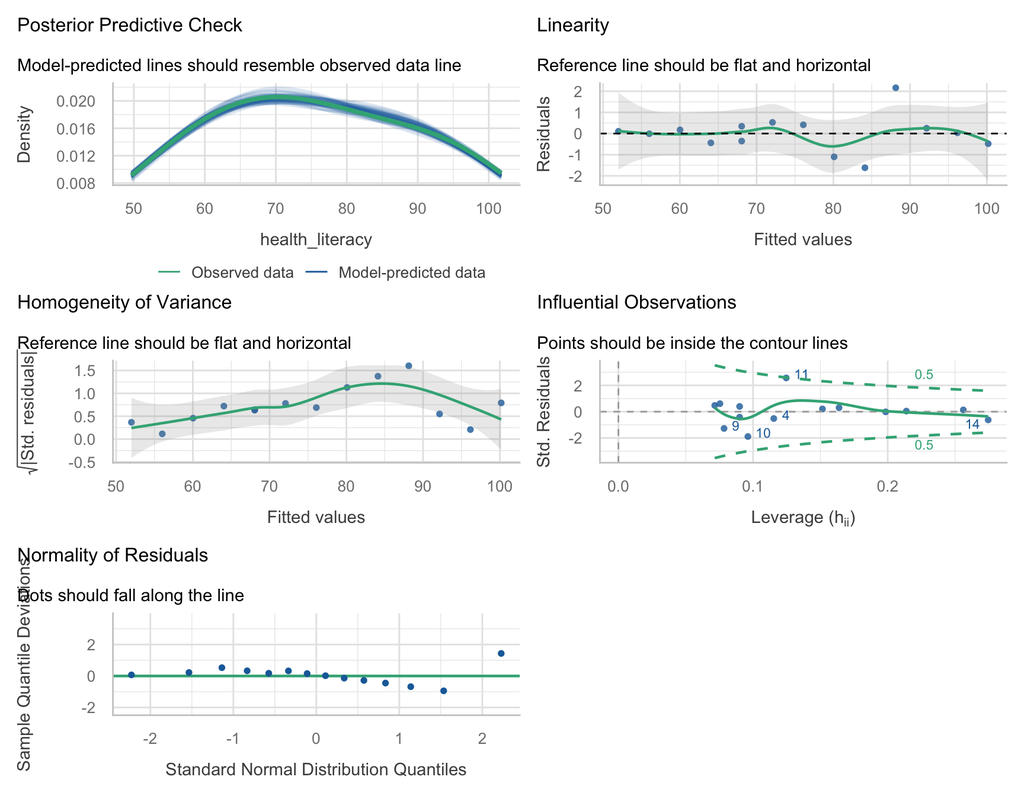

```r
diagnose(hom_border, health_literacy ~ education_yrs)
```

## Practice — Homoscedasticity

1. Describe in one sentence the difference between the **Shape** panel and the **Homogeneity** panel — they can look similar to beginners.
2. The income data fans *out*. Sketch what a dataset that fans *in* (spread shrinking as x grows) would look like. Is that also heteroscedasticity?
3. Why might “spending” naturally have unequal variance even when “calories burned” does not? Think about what drives each outcome.

# I — Influential Points

**The question:** is any single observation pulling the line around? We read the **Influential observations** panel (residuals vs leverage). Points that sit *outside the dashed contour* combine an unusual x-value (leverage) with a large residual (off the line) — the two ingredients of influence.

## Start with the bad one

A cholesterol screening where one record was fat-fingered: BMI = 42 paired with cholesterol = 130 (impossibly low for that BMI). A likely data-entry error.

```r
inf_bad <- tribble(
  ~bmi, ~cholesterol,
  19, 201,
  20, 212,
  21, 214,
  22, 218,
  23, 227,
  24, 231,
  25, 238,
  26, 235,
  27, 244,
  28, 252,
  29, 246,
  30, 252,
  31, 255,
  32, 258,
  42, 130
)
```

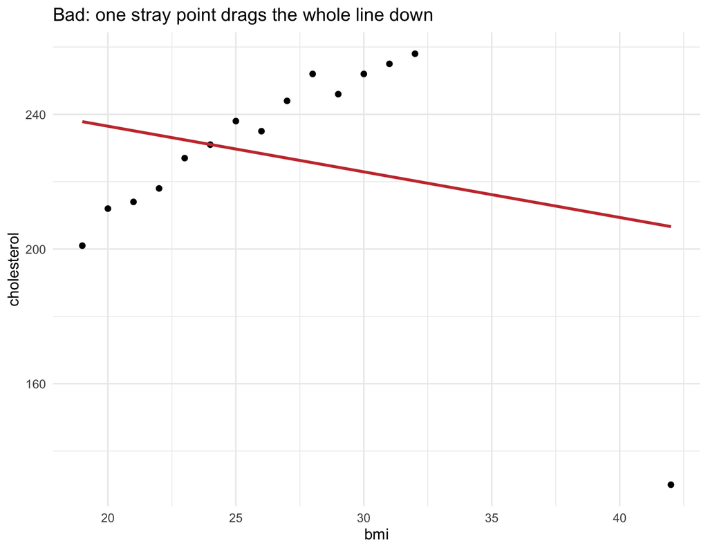

```r
ggplot(inf_bad, aes(bmi, cholesterol)) +
  geom_point(size = 2) +
  geom_smooth(method = "lm", se = FALSE, colour = "#C83B3B") +
  labs(title = "Bad: one stray point drags the whole line down") +
  theme_minimal(base_size = 14)
```

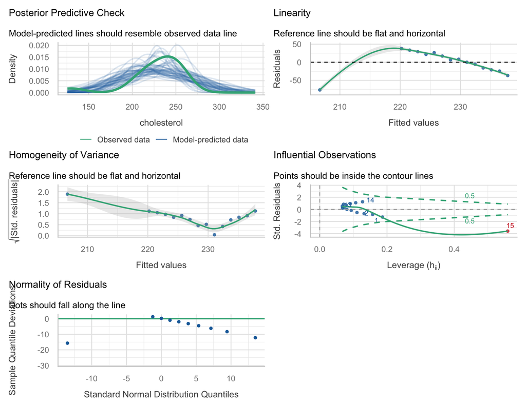

```r
diagnose(inf_bad, cholesterol ~ bmi)
```

> **What to point out:** in the *Influential observations* panel one point flies off to the right, past the dashed contour. It has both high leverage (BMI 42 is far from the pack) and a huge residual (way off the line). Removing it would visibly rotate the fit.

## Now the good one

The same screening, but clean — no point dominates.

```r
inf_good <- tribble(
  ~bmi, ~cholesterol,
  19, 201,
  20, 212,
  21, 214,
  22, 218,
  23, 227,
  24, 231,
  25, 238,
  26, 235,
  27, 244,
  28, 252,
  29, 246,
  30, 252,
  31, 255,
  32, 258
)
```

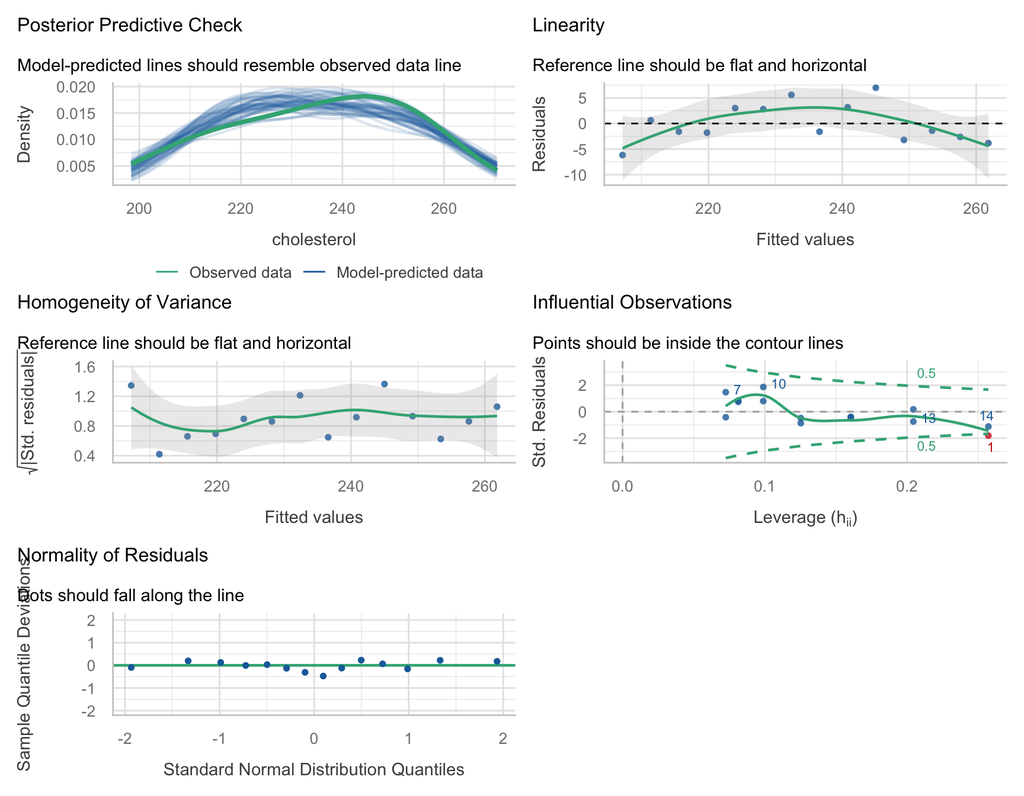

```r
diagnose(inf_good, cholesterol ~ bmi)
```

## The in-between one

```r
inf_border <- tribble(
  ~age, ~systolic_bp,
  30, 114,
  34, 119,
  38, 123,
  42, 126,
  46, 125,
  50, 134,
  54, 132,
  58, 137,
  62, 139,
  66, 143,
  33, 117,
  45, 126,
  57, 136,
  63, 141,
  78, 140
)
```

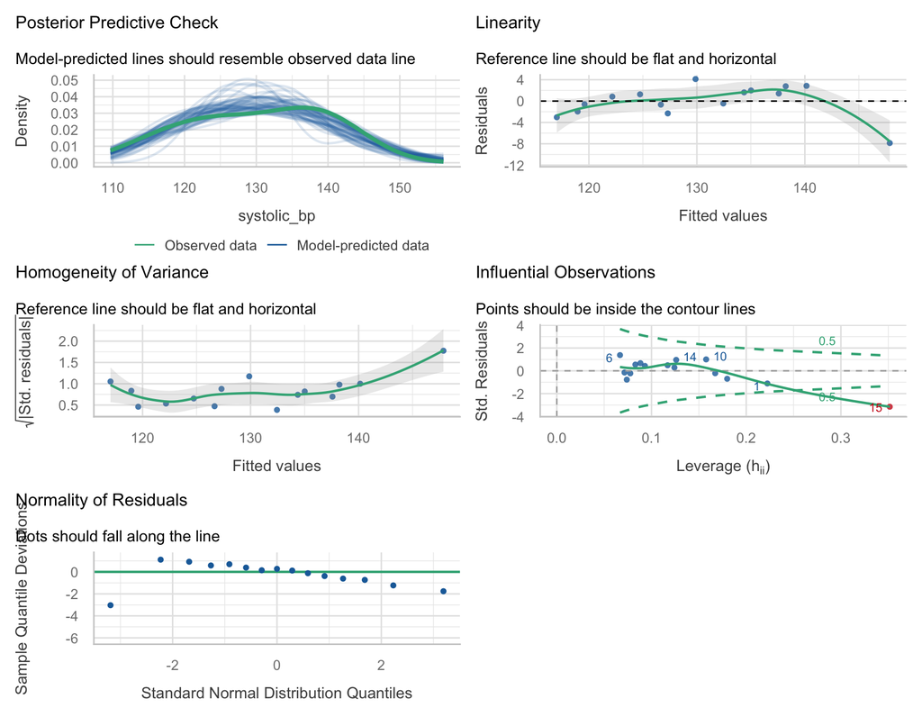

```r
diagnose(inf_border, systolic_bp ~ age)
```

## Practice — Influential points

# N — Normality of Residuals

**The question:** are the prediction errors roughly bell-shaped? We read the **Normality of residuals** panel (the Q–Q plot). Dots hugging the diagonal reference line are good; dots peeling away at the ends mean skew or heavy tails.

## Start with the bad one

```r
norm_bad <- tribble(
  ~poverty_rate, ~er_visits,
  5, 118,
  8, 97,
  10, 164,
  12, 118,
  15, 124,
  18, 194,
  20, 157,
  23, 159,
  26, 222,
  29, 201,
  32, 195,
  35, 292,
  38, 234,
  41, 284
)
```

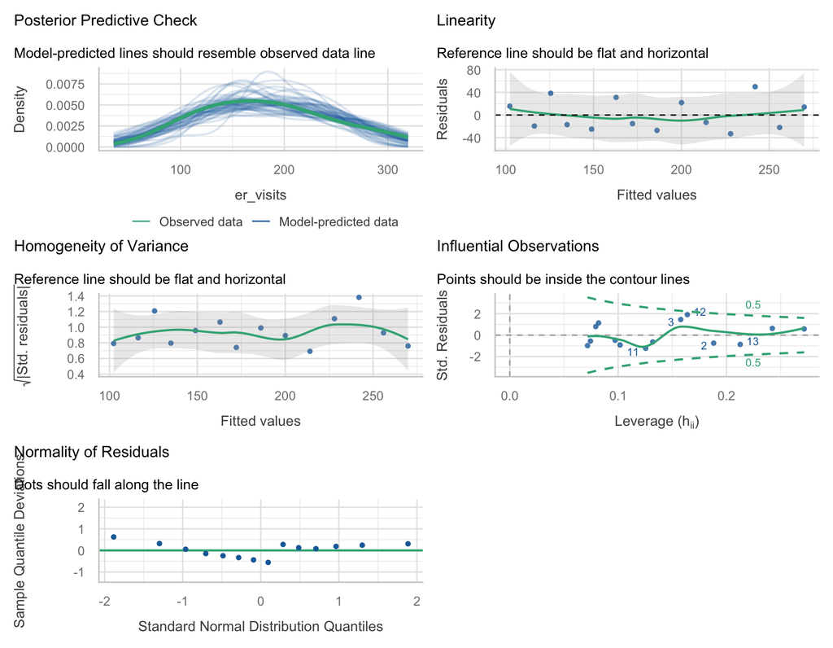

```r
diagnose(norm_bad, er_visits ~ poverty_rate)
```

## Now the good one

Height vs. lung capacity. Errors scatter symmetrically around the line.

```r
norm_good <- tribble(
  ~height_cm, ~lung_capacity,
  155, 3.4,
  157.7, 3.63,
  160.4, 3.46,
  163.1, 3.6,
  165.8, 4.17,
  168.5, 3.91,
  171.2, 4.43,
  173.8, 4.41,
  176.5, 4.41,
  179.2, 4.35,
  181.9, 4.49,
  184.6, 4.69,
  187.3, 4.59,
  190, 4.93
)
```

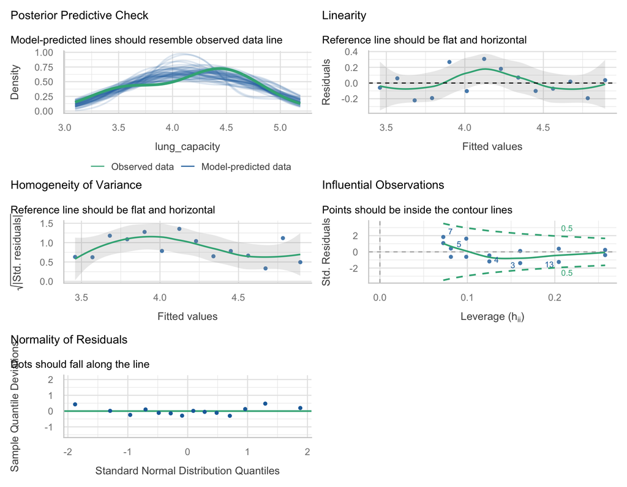

```r
diagnose(norm_good, lung_capacity ~ height_cm)
```

## The in-between one

Average nightly sleep vs. sick days per year. Most people follow the trend, with only a mild wiggle in the tails.

```r
norm_border <- tribble(
  ~sleep_hours, ~sick_days,
  5, 9.4,
  5.5, 9.4,
  6, 9.3,
  6.5, 7,
  7, 7.7,
  7, 7.5,
  7.5, 6.8,
  7.5, 8,
  8, 4.7,
  8, 7.4,
  8.5, 4.4,
  8.5, 4,
  9, 3.7,
  9, 4.8
)
```

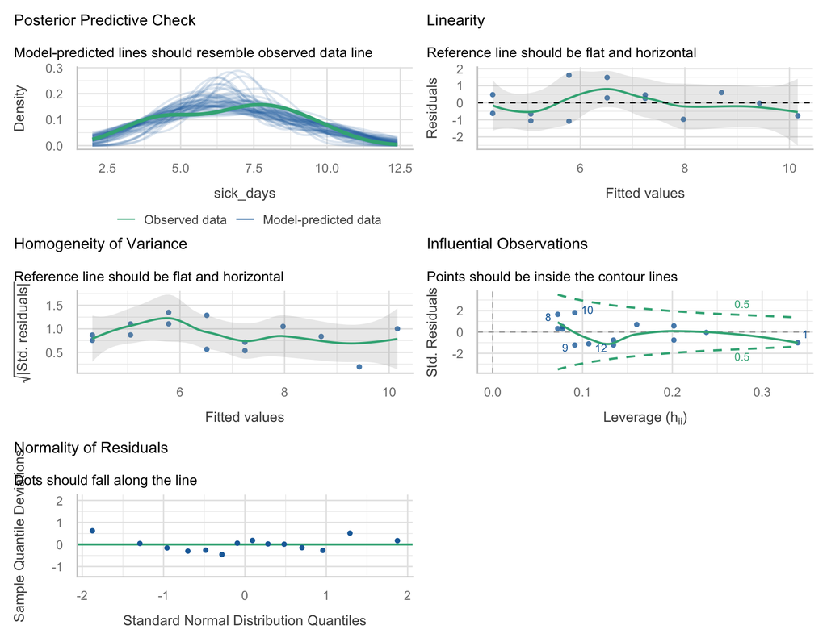

```r
diagnose(norm_border, sick_days ~ sleep_hours)
```

> **What to point out:** mostly on the line, with one or two points drifting at the ends but staying close to the band. A mild departure — usually fine, especially as samples grow.

## Practice — Normality

1. In the **bad** Q–Q plot, which end of the line do the points peel away from, and what does that tell you about the shape of the residual distribution?
2. Why is normality of residuals usually the *least* worrying of the SHIN checks for a large sample? (Hint: think about the Central Limit Theorem — covered in the Assumptions Explorer.)
3. Compare the **good** and **borderline** Q–Q plots. What specific visual cue tips you from “clearly fine” toward “keep an eye on it”?

# Wrap-up

| Letter | Check | Panel to read | Looks bad when… |
| --- | --- | --- | --- |
| S | Shape (linearity) | Linearity (resid vs fitted) | green line arches / U-shapes |
| H | Homoscedasticity | Homogeneity of variance | green line ramps up; spread fans |
| I | Influential points | Influential obs (resid vs leverage) | a point sits outside the contour |
| N | Normality | Normality of residuals (Q-Q) | dots peel off the diagonal |

- The workflow never changes: **fit → `check_model()` → find the panel → ask the question.**
- Real data is rarely perfectly good or obviously bad. Most of the judgement happens in the **borderline** zone — that is a skill, not a rule.
- We deliberately skipped *what goes wrong* and *how to fix it*. For the consequences, the formal tests (Breusch–Pagan, Shapiro–Wilk, Cook’s distance, RESET), and the remedies (transformations, robust SEs, sensitivity analysis), head to the **Regression Assumptions Explorer**.